```python
import pandas as pd
import numpy as np
import os

import requests
import bs4
import json
from IPython.display import HTML, Image
```

# Lecture 16 – Parsing, Regular Expressions

## DSC 80, Spring 2022

### Announcements

- Discussion 5 (on web scraping) is **today from 7-8:30PM**, and is due (for extra credit) on **Saturday, May 7th at 11:59PM**.
- Lab 6 is due on **Monday, May 9th at 11:59PM**.
- Project 3 is released, and is due on **Thursday, May 12th at 11:59PM**.
  - See [dsc80.com/project3](https://dsc80.com/project3/) for all the details.
  - **Try and download your data today!** There is no checkpoint, so you will have to hold yourself accountable.
- Midterm Exam grades are released! See [#935](https://campuswire.com/c/G325FA25B/feed/935) for details.
- Later this week, expect to see a "Grade Report" that contains a summary of your scores on all assignments this quarter along with a slip day counter.

### Agenda

- Example: Scraping the HDSI Faculty page.
- Example: Scraping quotes.
- String methods.
- Regular expressions.

## Example: Scraping the HDSI Faculty page

### HDSI Faculty page

Let's try and extract a list of HDSI Faculty from https://datascience.ucsd.edu/about/faculty/faculty/.

A good first step is to use the "inspect element" tool in our web browser.

```python
fac_response = requests.get('https://datascience.ucsd.edu/about/faculty/faculty/')
fac_response
```

```
<Response [200]>
```

```python
soup = bs4.BeautifulSoup(fac_response.text)
```

It seems like the relevant `<div>`s for faculty are the ones where the `data-entry-type` attribute is equal to `'individual'`. Let's find all of those using `find_all`.

```python
divs = soup.find_all('div', attrs={'data-entry-type': 'individual'})
```

```python
divs[0]
```

```
<div class="cn-list-row cn-list-item vcard individual faculty lecturers" data-entry-id="229" data-entry-slug="rod-albuyeh" data-entry-type="individual" id="rod-albuyeh">
<div class="cn-entry cn-accordion" id="entry-id-2296272d556adb37">
<div class="cn-left" style="min-width: 215px;">
<span class="cn-image-style"><span style="display: block; max-width: 100%; width: 215px"><img alt="Photo of Rod Albuyeh" class="cn-image photo" height="215" lazyload="1" loading="lazy" sizes="100vw" srcset="//datascience.ucsd.edu/wp-content/uploads/connections-images/rod-albuyeh/Rod-Albuyeh-Web-07dd…
</div> <!-- end cn-left-->
<div class="cn-right">
<h3 style="border-bottom: #182A48 1px solid; color:#182A48;"><a href="https://datascience.ucsd.edu/about/faculty/faculty/name/rod-albuyeh/" title="Rod Albuyeh"><span class="fn n notranslate"><span class="given-name">Rod</span> <span class="family-name">Albuyeh</span></span></a>
</h3><h4 class="title">Lecturer</h4>
<div class="cn-excerpt" id="cn-excerpt-2296272d556adb37">

			Albuyeh is Principal Data Scientist at Figure and part-time lecturer at the Halıcıoğlu Data Science Institute at UC San Diego.  He received his Ph.D. in Political Science at USC in 2016.  His specialties lie in anomaly detection for tabular time-series data and machine learning systems--with appl…

Research Interests: Machine Learning, Deployment, Scalable Systems<span class="cn-link-more"><a href="https://datascience.ucsd.edu/about/faculty/faculty/name/rod-albuyeh/">Learn More</a></span>
</div> <!--end cn-excerpt-->
<div class="cn-detail cn-hide" id="cn-detail-2296272d556adb37">
<div class="cn-bio" id="cn-bio-2296272d556adb37"><div class="cn-biography"><p>Albuyeh is Principal Data Scientist at Figure and part-time lecturer at the Halıcıoğlu Data Science Institute at UC San Diego.  He received his Ph.D. in Political Science at USC in 2016.  His specialties lie in anomaly det…
<p>Research Interests: Machine Learning, Deployment, Scalable Systems</p>
</div>
</div>
</div> <!--end cn-detail-->
</div> <!--end cn-right-->
</div> <!-- end cn-entry -->
</div>
```

Within here, we need to extract each faculty member's name. It seems like names are stored in the `title` attribute within an `<a>` tag.

```python
divs[0].find('a')
```

```
<a href="https://datascience.ucsd.edu/about/faculty/faculty/name/rod-albuyeh/" title="Rod Albuyeh"><span class="fn n notranslate"><span class="given-name">Rod</span> <span class="family-name">Albuyeh</span></span></a>
```

```python
divs[0].find('a').get('title')
```

```
'Rod Albuyeh'
```

We can also extract job titles:

```python
divs[0].find('h4')
```

```
<h4 class="title">Lecturer</h4>
```

```python
divs[0].find('h4').text
```

```
'Lecturer'
```

And bios:

```python
divs[0].find('div', attrs={'class': 'cn-bio'})
```

```
<div class="cn-bio" id="cn-bio-2296272d556adb37"><div class="cn-biography"><p>Albuyeh is Principal Data Scientist at Figure and part-time lecturer at the Halıcıoğlu Data Science Institute at UC San Diego.  He received his Ph.D. in Political Science at USC in 2016.  His specialties lie in anomaly det…
<p>Research Interests: Machine Learning, Deployment, Scalable Systems</p>
</div>
</div>
```

```python
divs[0].find('div', attrs={'class': 'cn-bio'}).text.strip()
```

```
'Albuyeh is Principal Data Scientist at Figure and part-time lecturer at the Halıcıoğlu Data Science Institute at UC San Diego.\xa0 He received his Ph.D. in Political Science at USC in 2016.\xa0 His specialties lie in anomaly detection for tabular time-series data and machine learning systems–with a…
```

Let's create a DataFrame consisting of names and bios for each faculty member.

```python
names = [div.find('a').get('title') for div in divs]
names[:5]
```

```
['Rod Albuyeh',
 'Ilkay Altintas',
 'Mikio Aoi',
 'Ery Arias-Castro',
 'Vineet Bafna']
```

```python
titles = [div.find('h4').text if div.find('h4') else '' for div in divs]
```

```python
bios = [div.find('div', attrs={'class': 'cn-bio'}).text.strip() for div in divs]
```

```python
faculty = pd.DataFrame().assign(name=names, title=titles, bio=bios)
faculty.head()
```

|  | name | title | bio |
| --- | --- | --- | --- |
| 0 | Rod Albuyeh | Lecturer | Albuyeh is Principal Data Scientist at Figure ... |
| 1 | Ilkay Altintas | Chief Data Science Officer, HDSI Founding Facu... | CHIEF DATA SCIENCE OFFICER, SDSC\nIlkay Altint... |
| 2 | Mikio Aoi | Assistant Professor | Dr. Aoi is a computational neuroscientist inte... |
| 3 | Ery Arias-Castro | Professor | Ery Arias-Castro received his Ph.D. in Statist... |
| 4 | Vineet Bafna | Professor | Vineet Bafna, Ph.D., is a Bioinformatics resea... |

Now we have a DataFrame!

```python
faculty[faculty['title'] == 'Lecturer']
```

|  | name | title | bio |
| --- | --- | --- | --- |
| 0 | Rod Albuyeh | Lecturer | Albuyeh is Principal Data Scientist at Figure ... |
| 31 | Suraj Rampure | Lecturer | Suraj Rampure is a Lecturer in the Halıcıoğlu ... |
| 42 | Janine Tiefenbruck | Lecturer | Tiefenbruck focuses her mathematics background... |

What if we want to get faculty members' pictures? It seems like we should look at the attributes of an `<img>` tag.

```python
divs[0].find('img')
```

```
<img alt="Photo of Rod Albuyeh" class="cn-image photo" height="215" lazyload="1" loading="lazy" sizes="100vw" srcset="//datascience.ucsd.edu/wp-content/uploads/connections-images/rod-albuyeh/Rod-Albuyeh-Web-07dd8c651b197a11107f1c858ce1e390.jpg 1x" title="Photo of Rod Albuyeh" width="215"/>
```

```python
divs[0].find('img').get('srcset')
```

```
'//datascience.ucsd.edu/wp-content/uploads/connections-images/rod-albuyeh/Rod-Albuyeh-Web-07dd8c651b197a11107f1c858ce1e390.jpg 1x'
```

```python
def show_picture(name):
    idx = names.index(name)
    url = divs[idx].find('img').get('srcset')
    url = 'https://' + url.strip('/').strip(' 1x')
    display(Image(url))
```

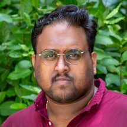

```python
show_picture('Suraj Rampure')
```

## Example: Scraping quotes

### Example: Scraping quotes

Let's scrape quotes from https://quotes.toscrape.com/.

[figure not shown]

Specifically, let's try to make a DataFrame that looks like the one below:

|  | quote | author | author_url | tags |
| --- | --- | --- | --- | --- |
| 0 | “The world as we have created it is a process of our thinking. It cannot be changed without changing our thinking.” | Albert Einstein | https://quotes.toscrape.com/author/Albert-Einstein | change,deep-thoughts,thinking,world |
| 1 | “It is our choices, Harry, that show what we truly are, far more than our abilities.” | J.K. Rowling | https://quotes.toscrape.com/author/J-K-Rowling | abilities,choices |
| 2 | “There are only two ways to live your life. One is as though nothing is a miracle. The other is as though everything is a miracle.” | Albert Einstein | https://quotes.toscrape.com/author/Albert-Einstein | inspirational,life,live,miracle,miracles |

### The plan

Eventually, we will create a single function – `quote_df` – which takes in an integer `n` and returns a **DataFrame** with the quotes on the **first `n` pages** of https://quotes.toscrape.com/.

To do this, we will define several helper functions:

- `download_page(i)`, which downloads a **single page** (page `i`) and returns a `BeautifulSoup` object of the response.
- `process_quote(div)`, which takes in a `<div>` tree corresponding to a **single quote** and returns a Series containing all of the relevant information for that quote.
- `process_page(divs)`, which takes in a list of `<div>` trees corresponding to a **single page** and returns a DataFrame containing all of the relevant information for all quotes on that page.

Key principle: some of our helper functions will make **requests**, and others will **parse**, but none will do both!

- Easier to debug and catch errors.
- Avoids unnecessary requests.

### Aside: f-strings in Python

- f-strings in Python provide a convenient way to format strings.
- To create an f-string, create a string with the character `f` **right before** the opening quote. Then, anything in the subsequent string that is inside `{curly brackets}` will be evaluated.

```python
f'2 + 3 = {2 + 3}'
```

```
'2 + 3 = 5'
```

```python
def make_greeting(name):
    return f"Hi {name}! 👋 Your name has {len(name)} characters, the first of which is {name[0]}."
```

```python
make_greeting('Billy')
```

```
'Hi Billy! 👋 Your name has 5 characters, the first of which is B.'
```

### Downloading a single page

```python
def download_page(i):
    url = f'https://quotes.toscrape.com/page/{i}'
    request = requests.get(url)
    return bs4.BeautifulSoup(request.text)
```

In `quote_df`, we will call `download_page` repeatedly – once for `i=1`, once for `i=2`, ..., `i = n`. For now, we will work with just page 5 (chosen arbitrarily).

```python
soup = download_page(5)
```

### Parsing a single page

Let's look at the page's source code (via "inspect element") to find where the quotes in the page are located.

```python
divs = soup.find_all('div', attrs={'class': 'quote'})
```

```python
divs[0]
```

```
<div class="quote" itemscope="" itemtype="http://schema.org/CreativeWork">
<span class="text" itemprop="text">“A reader lives a thousand lives before he dies, said Jojen. The man who never reads lives only one.”</span>
<span>by <small class="author" itemprop="author">George R.R. Martin</small>
<a href="/author/George-R-R-Martin">(about)</a>
</span>
<div class="tags">
            Tags:
            <meta class="keywords" content="read,readers,reading,reading-books" itemprop="keywords"/>
<a class="tag" href="/tag/read/page/1/">read</a>
<a class="tag" href="/tag/readers/page/1/">readers</a>
<a class="tag" href="/tag/reading/page/1/">reading</a>
<a class="tag" href="/tag/reading-books/page/1/">reading-books</a>
</div>
</div>
```

From this `<div>`, we can extract the quote, author name, author's URL, and tags.

```python
divs[0].find('span', attrs={'class': 'text'}).text
```

```
'“A reader lives a thousand lives before he dies, said Jojen. The man who never reads lives only one.”'
```

```python
divs[0].find('small', attrs={'class': 'author'}).text
```

```
'George R.R. Martin'
```

```python
divs[0].find('a').get('href')
```

```
'/author/George-R-R-Martin'
```

```python
divs[0].find('meta', attrs={'class': 'keywords'}).get('content')
```

```
'read,readers,reading,reading-books'
```

Let's write an intermediate function, `process_quote`, which takes in a `<div>` corresponding to a single quote and returns a **Series** containing the quote's information.

Note that this approach is different than the approach taken in the HDSI Faculty page example – there, we created each column of our final DataFrame separately, while here we are creating one **row** of our final DataFrame at a time.

```python
def process_quote(div):
    quote = div.find('span', attrs={'class': 'text'}).text
    author = div.find('small', attrs={'class': 'author'}).text
    author_url = 'https://quotes.toscrape.com' + div.find('a').get('href')
    tags = div.find('meta', attrs={'class': 'keywords'}).get('content')

    return pd.Series({'quote': quote, 'author': author, 'author_url': author_url, 'tags': tags})
```

```python
process_quote(divs[3])
```

```
quote         “If you can make a woman laugh, you can make h...
author                                           Marilyn Monroe
author_url    https://quotes.toscrape.com/author/Marilyn-Monroe
tags                                                 girls,love
dtype: object
```

Next, we can write a function that takes in a list of `<div>`s, calls the above function on each `<div>` in the list, and returns a **DataFrame**.

```python
def process_page(divs):
    return pd.DataFrame([process_quote(div) for div in divs])
```

```python
process_page(divs)
```

|  | quote | author | author_url | tags |
| --- | --- | --- | --- | --- |
| 0 | “A reader lives a thousand lives before he die... | George R.R. Martin | https://quotes.toscrape.com/author/George-R-R-... | read,readers,reading,reading-books |
| 1 | “You can never get a cup of tea large enough o... | C.S. Lewis | https://quotes.toscrape.com/author/C-S-Lewis | books,inspirational,reading,tea |
| 2 | “You believe lies so you eventually learn to t... | Marilyn Monroe | https://quotes.toscrape.com/author/Marilyn-Monroe |  |
| 3 | “If you can make a woman laugh, you can make h... | Marilyn Monroe | https://quotes.toscrape.com/author/Marilyn-Monroe | girls,love |
| 4 | “Life is like riding a bicycle. To keep your b... | Albert Einstein | https://quotes.toscrape.com/author/Albert-Eins... | life,simile |
| 5 | “The real lover is the man who can thrill you ... | Marilyn Monroe | https://quotes.toscrape.com/author/Marilyn-Monroe | love |
| 6 | “A wise girl kisses but doesn't love, listens ... | Marilyn Monroe | https://quotes.toscrape.com/author/Marilyn-Monroe | attributed-no-source |
| 7 | “Only in the darkness can you see the stars.” | Martin Luther King Jr. | https://quotes.toscrape.com/author/Martin-Luth... | hope,inspirational |
| 8 | “It matters not what someone is born, but what... | J.K. Rowling | https://quotes.toscrape.com/author/J-K-Rowling | dumbledore |
| 9 | “Love does not begin and end the way we seem t... | James Baldwin | https://quotes.toscrape.com/author/James-Baldwin | love |

### Putting it all together

```python
def quote_df(n):
    '''Returns a DataFrame containing the quotes on the first n pages of https://quotes.toscrape.com/.'''
    dfs = []
    for i in range(1, n + 1):
        # Download page n and create a BeautifulSoup object
        soup = download_page(i)

        # Create DataFrame using the information in that page
        divs = soup.find_all('div', attrs={'class': 'quote'})
        df = process_page(divs)

        # Append DataFrame to dfs
        dfs.append(df)

    # Stitch all DataFrames together
    return pd.concat(dfs).reset_index(drop=True)
```

```python
first_three_pages = quote_df(3)
first_three_pages.head()
```

|  | quote | author | author_url | tags |
| --- | --- | --- | --- | --- |
| 0 | “The world as we have created it is a process ... | Albert Einstein | https://quotes.toscrape.com/author/Albert-Eins... | change,deep-thoughts,thinking,world |
| 1 | “It is our choices, Harry, that show what we t... | J.K. Rowling | https://quotes.toscrape.com/author/J-K-Rowling | abilities,choices |
| 2 | “There are only two ways to live your life. On... | Albert Einstein | https://quotes.toscrape.com/author/Albert-Eins... | inspirational,life,live,miracle,miracles |
| 3 | “The person, be it gentleman or lady, who has ... | Jane Austen | https://quotes.toscrape.com/author/Jane-Austen | aliteracy,books,classic,humor |
| 4 | “Imperfection is beauty, madness is genius and... | Marilyn Monroe | https://quotes.toscrape.com/author/Marilyn-Monroe | be-yourself,inspirational |

The elements in the `'tags'` column are all strings, but they look like lists. This is not ideal, as we will see shortly.

### An extension

We could:

- Request information about each of the **authors** in the DataFrame.
  - See https://quotes.toscrape.com/author/Albert-Einstein/ for an example.
- Create a DataFrame of author information.
- Merge that DataFrame with `first_three_pages`.

```python
np.unique(first_three_pages['author_url'])
```

```
array(['https://quotes.toscrape.com/author/Albert-Einstein',
       'https://quotes.toscrape.com/author/Allen-Saunders',
       'https://quotes.toscrape.com/author/Andre-Gide',
       'https://quotes.toscrape.com/author/Bob-Marley',
       'https://quotes.toscrape.com/author/Douglas-Adams',
       'https://quotes.toscrape.com/author/Dr-Seuss',
       'https://quotes.toscrape.com/author/Eleanor-Roosevelt',
       'https://quotes.toscrape.com/author/Elie-Wiesel',
       'https://quotes.toscrape.com/author/Friedrich-Nietzsche',
       'https://quotes.toscrape.com/author/Garrison-Keillor',
       'https://quotes.toscrape.com/author/J-K-Rowling',
       'https://quotes.toscrape.com/author/Jane-Austen',
       'https://quotes.toscrape.com/author/Jim-Henson',
       'https://quotes.toscrape.com/author/Marilyn-Monroe',
       'https://quotes.toscrape.com/author/Mark-Twain',
       'https://quotes.toscrape.com/author/Mother-Teresa',
       'https://quotes.toscrape.com/author/Pablo-Neruda',
       'https://quotes.toscrape.com/author/Ralph-Waldo-Emerson',
       'https://quotes.toscrape.com/author/Steve-Martin',
       'https://quotes.toscrape.com/author/Thomas-A-Edison'], dtype=object)
```

```python
einstein = bs4.BeautifulSoup(requests.get('https://quotes.toscrape.com/author/Albert-Einstein').text)
```

```python
einstein.find('div', attrs={'class': 'author-description'}).text[:1000]
```

```
'\n        In 1879, Albert Einstein was born in Ulm, Germany. He completed his Ph.D. at the University of Zurich by 1909. His 1905 paper explaining the photoelectric effect, the basis of electronics, earned him the Nobel Prize in 1921. His first paper on Special Relativity Theory, also published in …
```

### Key takeaways

- Make as few requests as possible.
- Create a request and parsing plan **beforehand**.
- Create your output schema **beforehand**.
- Make requests and parse in **separate functions**!
- See Lab 6, Question 2 for a related example.

## Nested vs. flat data formats

### Nested vs. flat data formats

- **Nested** data formats, like HTML, JSON, and XML, allow us to represent hierarchical relationships between variables.
- **Flat** (i.e. tabular) data formats, like CSV, do not.

[figure not shown]

### Example: Scraping quotes, again

- Suppose we obtained the quotes data via an API and saved it to the file `data/quotes2scrape.json`.
- `quotes2scrape.json` is a **JSON records** file; each line is a valid JSON object, **but the entire document is not**.

```python
f = open(os.path.join('data', 'quotes2scrape.json'))
```

```python
json.loads(f.readline())
```

```
{'auth_url': 'http://quotes.toscrape.com/author/Albert-Einstein',
 'quote_auth': 'Albert Einstein',
 'quote_text': '“The world as we have created it is a process of our thinking. It cannot be changed without changing our thinking.”',
 'bio': 'In 1879, Albert Einstein was born in Ulm, Germany. He completed his Ph.D. at the University of Zurich by 1909. His 1905 paper explaining the photoelectric effect, the basis of electronics, earned him the Nobel Prize in 1921. His first paper on Special Relativity Theory, also published in 19…
 'dob': 'March 14, 1879',
 'tags': ['change', 'deep-thoughts', 'thinking', 'world']}
```

Note that for a single quote, we have keys for `'auth_url'`, `'quote_auth'`, `'quote_text'`, `'bio'`, `'dob'`, and `'tags'`.

Since each line is a separate JSON object, let's read in each line one at a time.

```python
L = [json.loads(x) for x in open(os.path.join('data', 'quotes2scrape.json'))]
```

Let's convert the result to a DataFrame.

```python
df = pd.DataFrame(L)
df.head()
```

|  | auth_url | quote_auth | quote_text | bio | dob | tags |
| --- | --- | --- | --- | --- | --- | --- |
| 0 | http://quotes.toscrape.com/author/Albert-Einstein | Albert Einstein | “The world as we have created it is a process ... | In 1879, Albert Einstein was born in Ulm, Germ... | March 14, 1879 | [change, deep-thoughts, thinking, world] |
| 1 | http://quotes.toscrape.com/author/J-K-Rowling | J.K. Rowling | “It is our choices, Harry, that show what we t... | See also: Robert GalbraithAlthough she writes ... | July 31, 1965 | [abilities, choices] |
| 2 | http://quotes.toscrape.com/author/Albert-Einstein | Albert Einstein | “There are only two ways to live your life. On... | In 1879, Albert Einstein was born in Ulm, Germ... | March 14, 1879 | [inspirational, life, live, miracle, miracles] |
| 3 | http://quotes.toscrape.com/author/Jane-Austen | Jane Austen | “The person, be it gentleman or lady, who has ... | Jane Austen was an English novelist whose work... | December 16, 1775 | [aliteracy, books, classic, humor] |
| 4 | http://quotes.toscrape.com/author/Marilyn-Monroe | Marilyn Monroe | “Imperfection is beauty, madness is genius and... | Marilyn Monroe (born Norma Jeane Mortenson; Ju... | June 01, 1926 | [be-yourself, inspirational] |

What data type is the `'tags'` column?

```python
df['tags'].iloc[0]
```

```
['change', 'deep-thoughts', 'thinking', 'world']
```

Let's save `df` to a CSV and read it back in.

```python
df.to_csv('out.csv')
```

```python
df_again = pd.read_csv('out.csv')
df_again.head()
```

|  | Unnamed: 0 | auth_url | quote_auth | quote_text | bio | dob | tags |
| --- | --- | --- | --- | --- | --- | --- | --- |
| 0 | 0 | http://quotes.toscrape.com/author/Albert-Einstein | Albert Einstein | “The world as we have created it is a process ... | In 1879, Albert Einstein was born in Ulm, Germ... | March 14, 1879 | ['change', 'deep-thoughts', 'thinking', 'world'] |
| 1 | 1 | http://quotes.toscrape.com/author/J-K-Rowling | J.K. Rowling | “It is our choices, Harry, that show what we t... | See also: Robert GalbraithAlthough she writes ... | July 31, 1965 | ['abilities', 'choices'] |
| 2 | 2 | http://quotes.toscrape.com/author/Albert-Einstein | Albert Einstein | “There are only two ways to live your life. On... | In 1879, Albert Einstein was born in Ulm, Germ... | March 14, 1879 | ['inspirational', 'life', 'live', 'miracle', '... |
| 3 | 3 | http://quotes.toscrape.com/author/Jane-Austen | Jane Austen | “The person, be it gentleman or lady, who has ... | Jane Austen was an English novelist whose work... | December 16, 1775 | ['aliteracy', 'books', 'classic', 'humor'] |
| 4 | 4 | http://quotes.toscrape.com/author/Marilyn-Monroe | Marilyn Monroe | “Imperfection is beauty, madness is genius and... | Marilyn Monroe (born Norma Jeane Mortenson; Ju... | June 01, 1926 | ['be-yourself', 'inspirational'] |

What data type is the `'tags'` column now?

```python
df_again['tags'].iloc[0]
```

```
"['change', 'deep-thoughts', 'thinking', 'world']"
```

### One-hot encoding

- So that we don't have to deal with lists within Series, we can **flatten** lists of tags so that there is **one column per tag**.
  - For example, consider the tag `'inspirational'`.
  - If a quote has a 1 in the `'inspirational'` column, it **was** tagged `'inspirational'`.
  - If a quote has a 0 in the `'inspirational'` column, it **was not** tagged `'inspirational'`.
- This process – of converting categorical variables into columns of 1s and 0s – is called **one-hot encoding**. We will revisit it in a few weeks.

```python
distinct_tags = np.unique(df['tags'].sum())
distinct_tags
```

```
array(['abilities', 'activism', 'adulthood', 'adventure', 'age',
       'alcohol', 'aliteracy', 'apathy', 'attributed',
       'attributed-no-source', 'authors', 'be-yourself', 'beatles',
       'better-life-empathy', 'bilbo', 'books', 'change', 'children',
       'chocolate', 'choices', 'christianity', 'classic', 'comedy',
       'connection', 'contentment', 'courage', 'death', 'deep-thoughts',
       'difficult', 'dreamers', 'dreaming', 'dreams', 'drug',
       'dumbledore', 'edison', 'education', 'elizabeth-bennet', 'failure',
       'fairy-tales', 'fairytales', 'faith', 'fantasy', 'fate', 'fear',
       'food', 'friends', 'friendship', 'girls', 'god', 'good',
       'growing-up', 'grown-ups', 'happiness', 'hate', 'heartbreak',
       'hope', 'humor', 'imagination', 'indifference', 'insanity',
       'inspiration', 'inspirational', 'integrity', 'jane-austen',
       'journey', 'knowledge', 'lack-of-friendship', 'lack-of-love',
       'learning', 'library', 'lies', 'life', 'literature', 'live',
       'live-death-love', 'lost', 'love', 'lying', 'marriage', 'mind',
       'miracle', 'miracles', 'misattributed-eleanor-roosevelt',
       'misattributed-john-lennon', 'misattributed-mark-twain',
       'misattributed-to-c-s-lewis', 'misattributed-to-einstein',
       'misattributed-to-mother-teresa', 'mistakes', 'music',
       'navigation', 'novelist-quotes', 'obvious', 'open-mind',
       'opposite', 'paraphrased', 'peace', 'philosophy', 'planning',
       'plans', 'poetry', 'quest', 'read', 'readers', 'reading',
       'reading-books', 'regrets', 'religion', 'romance', 'romantic',
       'self-indulgence', 'seuss', 'simile', 'simplicity', 'sinister',
       'sisters', 'success', 'sun', 'tea', 'the-hunger-games', 'thinking',
       'thought', 'travel', 'troubles', 'truth', 'understand',
       'understanding', 'unhappy-marriage', 'value', 'wander', 'wisdom',
       'women', 'world', 'write', 'writers', 'writing', 'yourself'],
      dtype='<U31')
```

Let's write a function that takes in the list of tags (`taglist`) for a given quote and returns the one-hot-encoded sequence of 1s and 0s for that quote.

```python
def flatten_tags(taglist):
    return pd.Series({k:1 for k in taglist}, dtype=float)

tags = df['tags'].apply(flatten_tags).fillna(0).astype(int)
tags.head()
```

|  | change | deep-thoughts | thinking | world | abilities | choices | inspirational | life | live | miracle | ... | christianity | faith | sun | adventure | better-life-empathy | difficult | grown-ups | write | writers | mind |
| --- | --- | --- | --- | --- | --- | --- | --- | --- | --- | --- | --- | --- | --- | --- | --- | --- | --- | --- | --- | --- | --- |
| 0 | 1 | 1 | 1 | 1 | 0 | 0 | 0 | 0 | 0 | 0 | ... | 0 | 0 | 0 | 0 | 0 | 0 | 0 | 0 | 0 | 0 |
| 1 | 0 | 0 | 0 | 0 | 1 | 1 | 0 | 0 | 0 | 0 | ... | 0 | 0 | 0 | 0 | 0 | 0 | 0 | 0 | 0 | 0 |
| 2 | 0 | 0 | 0 | 0 | 0 | 0 | 1 | 1 | 1 | 1 | ... | 0 | 0 | 0 | 0 | 0 | 0 | 0 | 0 | 0 | 0 |
| 3 | 0 | 0 | 0 | 0 | 0 | 0 | 0 | 0 | 0 | 0 | ... | 0 | 0 | 0 | 0 | 0 | 0 | 0 | 0 | 0 | 0 |
| 4 | 0 | 0 | 0 | 0 | 0 | 0 | 1 | 0 | 0 | 0 | ... | 0 | 0 | 0 | 0 | 0 | 0 | 0 | 0 | 0 | 0 |

5 rows × 137 columns

Let's combine this one-hot-encoded DataFrame with `df`.

```python
df_full = pd.concat([df, tags], axis=1).drop(columns='tags')
df_full.head()
```

|  | auth_url | quote_auth | quote_text | bio | dob | change | deep-thoughts | thinking | world | abilities | ... | christianity | faith | sun | adventure | better-life-empathy | difficult | grown-ups | write | writers | mind |
| --- | --- | --- | --- | --- | --- | --- | --- | --- | --- | --- | --- | --- | --- | --- | --- | --- | --- | --- | --- | --- | --- |
| 0 | http://quotes.toscrape.com/author/Albert-Einstein | Albert Einstein | “The world as we have created it is a process ... | In 1879, Albert Einstein was born in Ulm, Germ... | March 14, 1879 | 1 | 1 | 1 | 1 | 0 | ... | 0 | 0 | 0 | 0 | 0 | 0 | 0 | 0 | 0 | 0 |
| 1 | http://quotes.toscrape.com/author/J-K-Rowling | J.K. Rowling | “It is our choices, Harry, that show what we t... | See also: Robert GalbraithAlthough she writes ... | July 31, 1965 | 0 | 0 | 0 | 0 | 1 | ... | 0 | 0 | 0 | 0 | 0 | 0 | 0 | 0 | 0 | 0 |
| 2 | http://quotes.toscrape.com/author/Albert-Einstein | Albert Einstein | “There are only two ways to live your life. On... | In 1879, Albert Einstein was born in Ulm, Germ... | March 14, 1879 | 0 | 0 | 0 | 0 | 0 | ... | 0 | 0 | 0 | 0 | 0 | 0 | 0 | 0 | 0 | 0 |
| 3 | http://quotes.toscrape.com/author/Jane-Austen | Jane Austen | “The person, be it gentleman or lady, who has ... | Jane Austen was an English novelist whose work... | December 16, 1775 | 0 | 0 | 0 | 0 | 0 | ... | 0 | 0 | 0 | 0 | 0 | 0 | 0 | 0 | 0 | 0 |
| 4 | http://quotes.toscrape.com/author/Marilyn-Monroe | Marilyn Monroe | “Imperfection is beauty, madness is genius and... | Marilyn Monroe (born Norma Jeane Mortenson; Ju... | June 01, 1926 | 0 | 0 | 0 | 0 | 0 | ... | 0 | 0 | 0 | 0 | 0 | 0 | 0 | 0 | 0 | 0 |

5 rows × 142 columns

```python
df_full[df_full['inspirational'] == 1].head()
```

|  | auth_url | quote_auth | quote_text | bio | dob | change | deep-thoughts | thinking | world | abilities | ... | christianity | faith | sun | adventure | better-life-empathy | difficult | grown-ups | write | writers | mind |
| --- | --- | --- | --- | --- | --- | --- | --- | --- | --- | --- | --- | --- | --- | --- | --- | --- | --- | --- | --- | --- | --- |
| 2 | http://quotes.toscrape.com/author/Albert-Einstein | Albert Einstein | “There are only two ways to live your life. On... | In 1879, Albert Einstein was born in Ulm, Germ... | March 14, 1879 | 0 | 0 | 0 | 0 | 0 | ... | 0 | 0 | 0 | 0 | 0 | 0 | 0 | 0 | 0 | 0 |
| 4 | http://quotes.toscrape.com/author/Marilyn-Monroe | Marilyn Monroe | “Imperfection is beauty, madness is genius and... | Marilyn Monroe (born Norma Jeane Mortenson; Ju... | June 01, 1926 | 0 | 0 | 0 | 0 | 0 | ... | 0 | 0 | 0 | 0 | 0 | 0 | 0 | 0 | 0 | 0 |
| 7 | http://quotes.toscrape.com/author/Thomas-A-Edison | Thomas A. Edison | “I have not failed. I've just found 10,000 way... | Thomas Alva Edison was an American inventor, s... | February 11, 1847 | 0 | 0 | 0 | 0 | 0 | ... | 0 | 0 | 0 | 0 | 0 | 0 | 0 | 0 | 0 | 0 |
| 10 | http://quotes.toscrape.com/author/Marilyn-Monroe | Marilyn Monroe | “This life is what you make it. No matter what... | Marilyn Monroe (born Norma Jeane Mortenson; Ju... | June 01, 1926 | 0 | 0 | 0 | 0 | 0 | ... | 0 | 0 | 0 | 0 | 0 | 0 | 0 | 0 | 0 | 0 |
| 16 | http://quotes.toscrape.com/author/Elie-Wiesel | Elie Wiesel | “The opposite of love is not hate, it's indiff... | Eliezer Wiesel was a Romania-born American nov... | September 30, 1928 | 0 | 0 | 0 | 0 | 0 | ... | 0 | 0 | 0 | 0 | 0 | 0 | 0 | 0 | 0 | 0 |

5 rows × 142 columns

Note that this DataFrame representation of the response JSON takes up much more space than the original JSON. Why is that?

## String methods, revisited

### Transitioning

[figure not shown]

- We've spent a lot of time at the "Find and Clean Data" stage.
- Today, we're going to start working with text data.
  - First, it will be in the context of cleaning data.
  - Starting next week, it will be in the context of modeling and prediction.

### Joining on text

Consider the following two DataFrames (see [this presentation](https://docs.google.com/presentation/d/1xQsqa7e3xDZ9nBiekbSBOecwvQm8pSVGa-FBoV6aJ7E/edit#slide=id.g11197671c7e_0_813)) for inspiration).

```python
codes = pd.read_csv(os.path.join('data', 'codes.csv'))
programs = pd.read_csv(os.path.join('data', 'programs.csv'))

display(codes)
display(programs)
```

|  | department | code |
| --- | --- | --- |
| 0 | Data Sci. | DSC |
| 1 | Computer Sci. and Eng. | CSE |
| 2 | Biology (Lower Division) | BILD |
| 3 | German Stud. | LTGM |

|  | department | programs |
| --- | --- | --- |
| 0 | data science | 3 |
| 1 | computer science & engineering | 5 |
| 2 | biology - lower division | 4 |
| 3 | german studies | 2 |

What would happen if we try to merge the two DataFrames on `'department'`?

```python
codes.merge(programs, on='department')
```

|  | department | code | programs |
| --- | --- | --- | --- |

### String canonicalization

- One solution is to **canonicalize** both `'department'` columns, so that there is just a single way to format each department's name **in both DataFrames**.
- We can do this by implementing a `canonicalize_department` function, which takes in a department's name as a string and reformats it.
- `canonicalize_department` should:
  - Fix cases (upper vs. lower).
  - Standardize variants of words – e.g. `'eng.'` vs `'engineering'`.
  - Fix punctuation – e.g. `'&'` vs. `'and'`.

```python
display(codes)
display(programs)
```

|  | department | code |
| --- | --- | --- |
| 0 | Data Sci. | DSC |
| 1 | Computer Sci. and Eng. | CSE |
| 2 | Biology (Lower Division) | BILD |
| 3 | German Stud. | LTGM |

|  | department | programs |
| --- | --- | --- |
| 0 | data science | 3 |
| 1 | computer science & engineering | 5 |
| 2 | biology - lower division | 4 |
| 3 | german studies | 2 |

```python
def canonicalize_department(d):
    return (d
           .lower()
           .replace('sci.', 'science')
           .replace('stud.', 'studies')
           .replace('eng.', 'engineering')
           .replace('&', 'and')
           .replace('(', '- ')
           .replace(')', '')
           )
```

```python
codes['department_clean'] = codes['department'].apply(canonicalize_department)
programs['department_clean'] = programs['department'].apply(canonicalize_department)

display(codes)
display(programs)
```

|  | department | code | department_clean |
| --- | --- | --- | --- |
| 0 | Data Sci. | DSC | data science |
| 1 | Computer Sci. and Eng. | CSE | computer science and engineering |
| 2 | Biology (Lower Division) | BILD | biology - lower division |
| 3 | German Stud. | LTGM | german studies |

|  | department | programs | department_clean |
| --- | --- | --- | --- |
| 0 | data science | 3 | data science |
| 1 | computer science & engineering | 5 | computer science and engineering |
| 2 | biology - lower division | 4 | biology - lower division |
| 3 | german studies | 2 | german studies |

Now, we can join `codes` with `programs` on `'department_clean'`.

```python
codes.merge(programs, on='department_clean')
```

|  | department_x | code | department_clean | department_y | programs |
| --- | --- | --- | --- | --- | --- |
| 0 | Data Sci. | DSC | data science | data science | 3 |
| 1 | Computer Sci. and Eng. | CSE | computer science and engineering | computer science & engineering | 5 |
| 2 | Biology (Lower Division) | BILD | biology - lower division | biology - lower division | 4 |
| 3 | German Stud. | LTGM | german studies | german studies | 2 |

### Reflection

The process of **string canonicalization** is very brittle.

- `canonicalize_department` was hyper-specific to the four department names we had access to.
- We don't know if it'll work for other departments.

### The limitations of string methods

How can we extract the date and time from the following **log** string, using just Python string methods?

```
132.249.20.188 - - [05/May/2022:14:26:15 -0800] "GET /my/home/ HTTP/1.1" 200 2585
```

### Parsing log strings

```python
s = '''132.249.20.188 - - [05/May/2022:14:26:15 -0800] "GET /my/home/ HTTP/1.1" 200 2585'''
```

```python
full_date = s.split('[')[1].split(']')[0]
full_date
```

```
'05/May/2022:14:26:15 -0800'
```

```python
day, month, rest = full_date.split('/')
day, month, rest
```

```
('05', 'May', '2022:14:26:15 -0800')
```

```python
year, hour, minute, second = rest.split(':')
second = second[:2]
year, hour, minute, second
```

```
('2022', '14', '26', '15')
```

```python
year, day, month, hour, minute, second
```

```
('2022', '05', 'May', '14', '26', '15')
```

Alternatively:

```python
pd.to_datetime(full_date[:-6], format='%d/%b/%Y:%H:%M:%S')
```

```
Timestamp('2022-05-05 14:26:15')
```

That was annoying! Let's see if there's a better way to extract the same information.

## Regular expressions

### This works...?

```python
s
```

```
'132.249.20.188 - - [05/May/2022:14:26:15 -0800] "GET /my/home/ HTTP/1.1" 200 2585'
```

```python
import re
re.findall('\[(\d)+\/(\w+)\/(\d+):(\d+):(\d+):(\d+)\s.*\]', s)[0]
```

```
('5', 'May', '2022', '14', '26', '15')
```

## 🤔🤯

### Regular expressions

- A regular expression, or **regex** for short, is a sequence of characters used to **match patterns in strings**.
  - For example, `[1-9][0-9]{2}-[0-9]{3}-[0-9]{4}` matches US phone numbers of the form `'XXX-XXX-XXXX'`.
- They are very powerful and widely used.
- However, they are quite difficult to read.

### regex101.com

- Next class, we will learn how to use regular expressions in Python using the `re` package.
- However, when crafting regular expressions, it is helpful to work in an environment that provides syntax highlighting and details.
- **regex101.com does exactly that – use it!**
  - [This link](https://regex101.com/r/ESor65/1) will bring you to the phone number example.

### Regex building blocks 🧱

The four main building blocks for all regexes are shown below ([table source](https://www.cs.princeton.edu/courses/archive/spring17/cos226/lectures/54RegularExpressions.pdf), [inspiration](https://docs.google.com/presentation/d/1xQsqa7e3xDZ9nBiekbSBOecwvQm8pSVGa-FBoV6aJ7E/edit#slide=id.g11197671c7e_0_919)).

| operation | order of op. | example | matches ✅ | does not match ❌ |
| --- | --- | --- | --- | --- |
| **concatenation** | 3 | `AABAAB` | AABAAB | every other string |
| **or** | 4 | `AA\|BAAB` | AA, BAAB | every other string |
| **closure** (zero or more) | 2 | `AB*A` | AA, ABBBBBBA | AB, ABABA |
| **parentheses** | 1 | `A(A\|B)AAB` `(AB)*A` | AAAAB, ABAAB A, ABABABABA | every other string AA, ABBA |

Note that `|`, `(`, `)`, and `*` are **special characters**, not literals. They manipulate the characters around them.

`AB*A` matches strings with an `'A'`, followed by zero or more `'B'`s, and then an `'A'`.

✅ `'AA'`, `'ABA'`, `'ABBBBBBBBBBBBBBA'`  
❌ `'AB'`, `'ABAB'`

`(AB)*A` matches strings with zero or more `'AB'`s, followed by an `'A'`.

✅ `'A'`, `'ABA'`, `'ABABABABA'`  
❌ `'AA'`, `'ABBBBBBBA'`, `'ABAB'`

### Example 1

Write a regular expression that matches `'billy'`, `'billlly'`, `'billlllly'`, etc.

- First, think about how to match strings with any even number of `'l'`s, including zero `'l'`s (i.e. `'biy'`).
- Then, think about how to match only strings with a **positive even** number of `'l'`s.

**✅ Click here to see the answer **after** you've tried it yourself at regex101.com.**

`bi(ll)*y` will match any even number of `'l'`s, including 0. To match only a positive even number of `'l'`s, we'd need to first "fix into place" two `'l'`s, and then follow that up with zero or more pairs of `'l'`s. This specifies the regular expression `bill(ll)*y`.

### Example 2

Write a regular expression that matches `'billy'`, `'billlly'`, `'biggy'`, `'biggggy'`, etc.

Specifically, it should match any string with a **positive even** number of `'l'`s in the middle, or a **positive even** number of `'g'`s in the middle.

**✅ Click here to see the answer **after** you've tried it yourself at regex101.com.**

Possible answers: `bi(ll(ll)\*|gg(gg)\*)y` or `bill(ll)\*y|bigg(gg)\*y`.  
Note, `bill(ll)\*|gg(gg)\*y` is **not** a valid answer! This is because "concatenation" comes before "or" in the order of operations. This regular expression would match strings that match `bill(ll)\*`, like `'billll'`, OR strings that match `gg(gg)\*y`, like `'ggy'`.

## Summary, next time

### Summary

- When writing scraping code:
  - Use "inspect element" to identify the names of tags and attributes that are relevant to the information you want to extract.
  - Separate your logic for making requests and for parsing.
- Regular expressions allow us to match patterns in strings.
- **Next time:** More regex syntax. Using regex in Python.
  - You **don't** need to memorize syntax, you just need to know what is possible.
  - We will look at some "cheat sheets" next class.
- **For fun (and practice):** Play [Regex Golf](https://alf.nu/RegexGolf?world=regex&level=r00)!